# Trading and investment account summary

# For 2020-08-12

Summary text: The equity value of my live trading portfolio changed by 2.48 % (US$ 797.51 ) from US$ 32146.32 to US$ 32943.83 today ( 2020-08-12 ). The trading proceeds in my live account were US$ -572.72 . The book proceeds in my portfolio changed from US$ 406.26 to US$ 1776.51

## Portfolio

The below table shows the current positions in the live account as well as their current and total performance. “book_proceed” indicates the unrealized profit in that position.

| symbol | close | closePerc | Total_Change_close | entry_price | position | position_size | entry_position | totalPerc | book_proceed | sector |
| --- | --- | --- | --- | --- | --- | --- | --- | --- | --- | --- |
| BRK.B | 213.16 | 0.26 | 28 | 195.40 | 50 | 10658.00 | 9770.15 | 8.33 | 887.85 | Finance |
| KWEB | 67.67 | 1.53 | 112.2 | 68.40 | 110 | 7443.70 | 7523.76 | -1.08 | -80.06 | Miscellaneous |
| EZA | 37.04 | 1.56 | -114 | 38.54 | -200 | -7408.00 | -7708.00 | 4.05 | 300 | Miscellaneous |
| SEAS | 18.06 | -0.22 | 15.6 | 18.20 | -390 | -7043.40 | -7099.06 | 0.79 | 55.66 | Consumer Services |
| CAKE | 27.12 | 0.48 | 19.5 | 23.15 | 150 | 4068.00 | 3472.28 | 14.64 | 595.72 | Consumer Services |
| JWN | 16.90 | 0.06 | 2.25 | 15.03 | 225 | 3802.50 | 3382.48 | 11.05 | 420.01 | Retail Trade |
| SQ | 139.02 | 0.55 | 19.13 | 141.33 | 25 | 3475.50 | 3533.37 | -1.67 | -57.87 | Technology Services |
| INDA | 33.20 | 1.03 | 34 | 33.05 | 100 | 3320.00 | 3304.99 | 0.45 | 15.01 | Miscellaneous |
| TSLA | 1554.42 | 13.13 | 360.85 | 1405.56 | 2 | 3108.85 | 2811.11 | 9.58 | 297.73 | Consumer Durables |
| MIK | 8.37 | 3.59 | 101.5 | 8.51 | 350 | 2929.50 | 2979.42 | -1.7 | -49.92 | Retail Trade |
| SLV | 23.40 | 0.3 | 7.68 | 22.13 | 110 | 2573.98 | 2434.80 | 5.41 | 139.18 | Miscellaneous |
| TPR | 15.57 | 0.26 | 6 | 14.67 | 150 | 2335.50 | 2201.24 | 5.75 | 134.26 | Retail Trade |
| V | 198.67 | 0.44 | 8.7 | 194.66 | 10 | 1986.70 | 1946.64 | 2.02 | 40.06 | Finance |
| WPM | 49.38 | 0.33 | 6.4 | 55.66 | 40 | 1975.20 | 2226.53 | -12.72 | -251.33 | Non-Energy Minerals |
| LMND | 60.68 | -3.3 | -62.1 | 78.07 | 30 | 1820.40 | 2342.14 | -28.66 | -521.74 | Finance |
| SWKS | 147.56 | 4.4 | 62.2 | 131.85 | 10 | 1475.60 | 1318.50 | 10.65 | 157.1 | Electronic Technology |
| CAT | 142.54 | 0.04 | 0.5 | 142.04 | 10 | 1425.40 | 1420.40 | 0.35 | 5 | Producer Manufacturing |
| XOM | 44.09 | -1.96 | -28.16 | 44.00 | 32 | 1410.88 | 1408.10 | 0.2 | 2.78 | Energy Minerals |
| LUV | 35.25 | -0.14 | -2 | 36.08 | 40 | 1410.00 | 1443.30 | -2.36 | -33.3 | Transportation |
| HD | 281.53 | 2.42 | 33.25 | 266.54 | 5 | 1407.65 | 1332.70 | 5.32 | 74.95 | Retail Trade |
| EPHE | 27.14 | 2.26 | -30 | 25.67 | -50 | -1357.00 | -1283.40 | -5.42 | -73.6 | Miscellaneous |
| UNM | 19.21 | -0.67 | -9.1 | 19.50 | 70 | 1344.70 | 1365.00 | -1.51 | -20.3 | Finance |
| PPLT | 87.25 | -1.21 | -16.05 | 89.44 | 15 | 1308.75 | 1341.55 | -2.51 | -32.8 | Miscellaneous |
| UPWK | 14.67 | 5.09 | 50.41 | 14.48 | 71 | 1041.57 | 1028.24 | 1.28 | 13.33 | Technology Services |
| PALL | 200.32 | 1.52 | 14.95 | 219.68 | 5 | 1001.60 | 1098.40 | -9.66 | -96.8 | Miscellaneous |
| RVLV | 19.46 | 4.01 | 37.5 | 15.92 | 50 | 973.00 | 796.00 | 18.19 | 177 | Retail Trade |
| IAU | 18.20 | -0.44 | -4 | 19.30 | 50 | 910.00 | 965.00 | -6.04 | -55 | Miscellaneous |
| PRU | 69.91 | -1.15 | -8.1 | 71.74 | 10 | 699.10 | 717.40 | -2.62 | -18.3 | Finance |
| ILMN | 344.15 | 0.84 | 5.74 | 346.12 | 2 | 688.30 | 692.24 | -0.57 | -3.94 | Health Technology |
| GOLD | 26.17 | -0.31 | -2 | 27.48 | 25 | 654.25 | 686.88 | -4.99 | -32.62 | Non-Energy Minerals |
| CRUS | 63.71 | 0.3 | 1.9 | 71.60 | 10 | 637.10 | 716.05 | -12.39 | -78.95 | Electronic Technology |
| FIZZ | 62.94 | 1.52 | 9.4 | 68.20 | 10 | 629.40 | 682.00 | -8.36 | -52.6 | Consumer Non-Durables |
| GDX | 39.26 | 0.51 | 3 | 43.89 | 15 | 588.90 | 658.39 | -11.8 | -69.49 | Miscellaneous |
| NFLX | 475.47 | 1.89 | 8.84 | 486.00 | 1 | 475.47 | 486.00 | -2.21 | -10.53 | Consumer Services |

| symbol | close | closePerc | Total_Change_close | entry_price | position | position_size | entry_position | totalPerc | book_proceed | sector |
| --- | --- | --- | --- | --- | --- | --- | --- | --- | --- | --- |
| Summary | NA | NA | 673.99 | NA | 2423 | 83387.89 | NA | 2.13 | 1776.508 | NA |

[interactive chart not shown]

The performance of my live stock portfolio/trading account vs. my paper trading account and the benchmark ‘SPY’, the US large cap stock market index ETF in percent since June 09 2020.

[interactive chart not shown]

This plot shows a summary of the trading activity on that day. Above 0 is a gain, below is a loss. TRUE indicated live trading account, FALSE is paper trading. A buy side trade is a closed short sale trade and sell side trade is a closed long trade.

[interactive chart not shown]

My current portfolio sorted by sectors. The plot reads clock-wise. Positions below 0 are short positions. Clicking a slice of the pie chart directs to marketwatch.com for further information.

[interactive chart not shown]

These two plots indicate the composition of my portfolio and the change of it over the past week.

[interactive chart not shown]

The inner circle is Monday, the outer circle is Friday.

[interactive chart not shown]

The colors in this plot indicate the daily percentage change of each stock in my portfolio.

[interactive chart not shown]

I classified the stocks in my portfolio by sector. The area represents the size of the position in the portfolio. Long postions

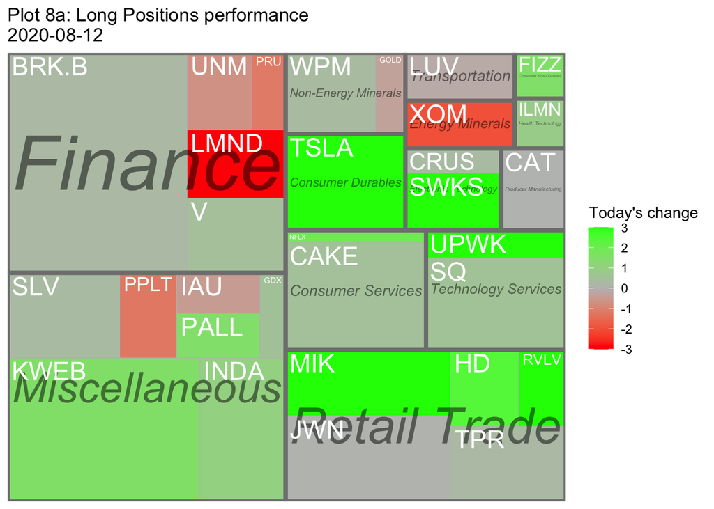

Short postions

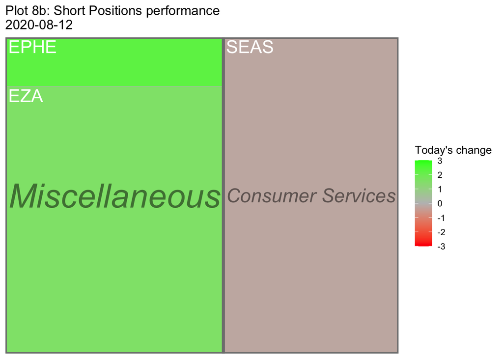

S&P 500 stocks colored by last day performance.

Outliers skew the colors, making the other stocks look pale. I restricted the colors to max of 3 and -3% change. Every stock having higher or lower than 3% change has the same color.

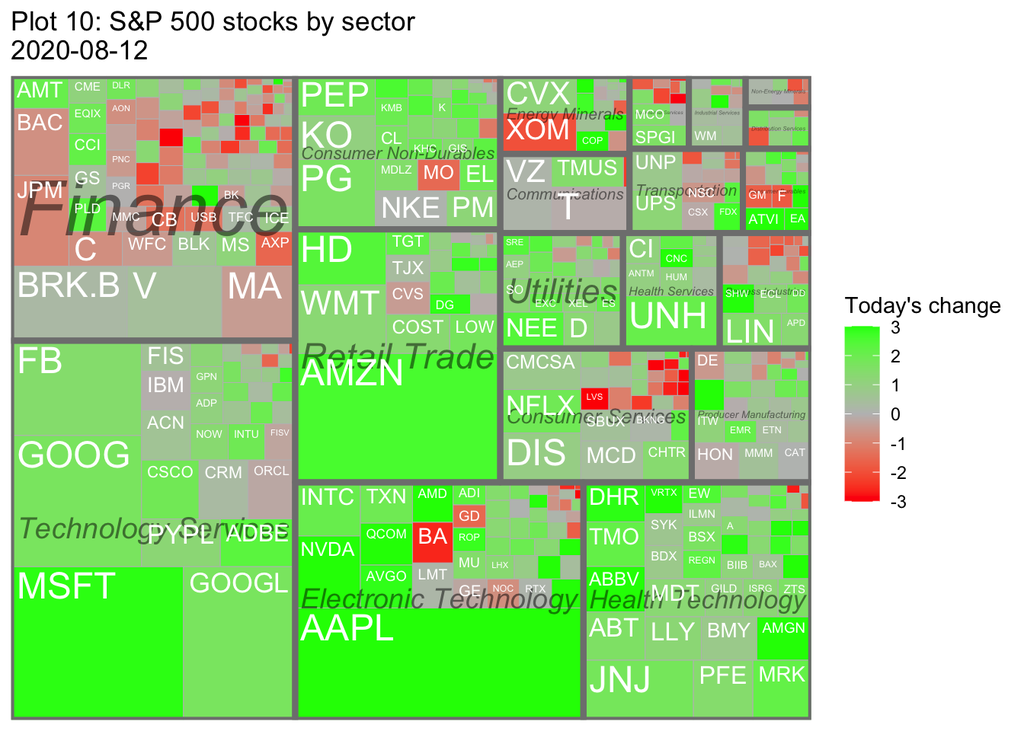

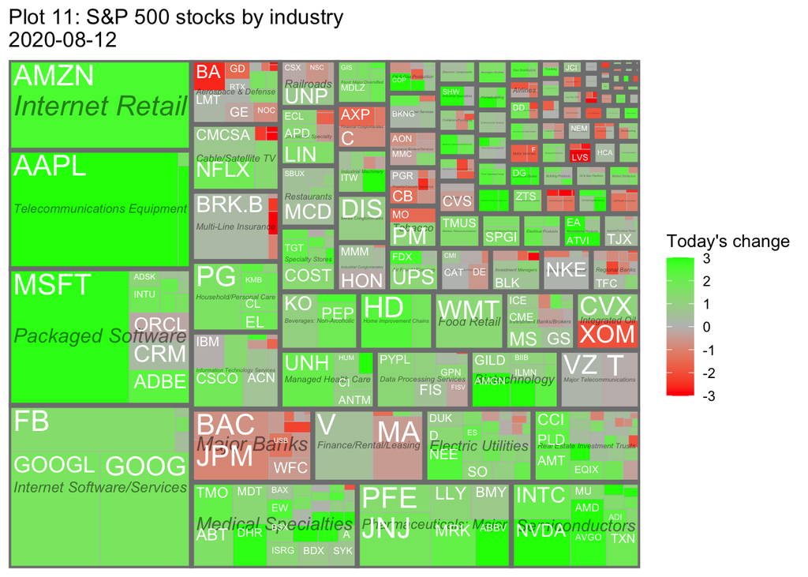